# Chapter 4 - Exercise Solutions

## Hard.

**4H1.** !Kung census data: Provide predicted heights and 89% intervals for the following weights of individuals.

```r
weights <- c(46.95, 43.72, 64.78, 32.59, 54.63)
```

For this, I reuse the model `m4.3` from above and simulate heights for the individuals above by hand:

```r
post <- extract.samples(m4.3)
sim.height <- sapply( weights, function(weight) {
  rnorm(
    n = nrow(post),
    mean = post$a + post$b * ( weight - xbar ),
    sd = post$sigma
  )
})
```

Computing the mean and 89% compatibility interval using `PI()` gives us:

```r
height.PI <- apply(sim.height, 2, PI, prob=0.89)
height.mean <- apply(sim.height, 2, mean)

pred_df <- data.frame("individual"=1:5, "weight"=weights, "exptected_height"=height.mean,
                      "PI_89_lower"=height.PI[1,], "PI_89_upper"=height.PI[2,])
pred_df
```

```
  individual weight exptected_height PI_89_lower PI_89_upper
1          1   47.0              156         148         165
2          2   43.7              153         145         162
3          3   64.8              172         164         180
4          4   32.6              143         135         152
5          5   54.6              163         155         172
```

**4H2.** Select the rows from the `Howell1` data with age below 18 years.

1. Fit a linear regression to these data, using `quap()`.

I will use the same model as above but adapt the prior for $\alpha$ to account for lower heights:

```r
d18 <- d[ d$age < 18, ]
xbar <- mean( d18$weight )

model18 <- quap(
  alist(
    height ~ dnorm( mu, sigma) ,
    mu <- a + b * ( weight - xbar )  ,
    a ~ dnorm( 156, 20) ,
    b ~ dlnorm( 0, 1 ) ,
    sigma ~ dunif(0, 50)
  ),
  data=d18
)
precis(model18)
```

```
        mean     sd   5.5%  94.5%
a     108.36 0.6086 107.39 109.34
b       2.72 0.0683   2.61   2.83
sigma   8.44 0.4306   7.75   9.13
```

As above, since the weight values are centered, the intercept `a` corresponds to the average height, which is here 108.3. This is much lower than in the model above (but expected since the individuals in this data set are younger). The slope `b` is interpreted such that for every 10kg heavier, an individual is expected to be 27cm taller. The standard deviation `sigma` in this model is higher than in the one above, suggesting a higher uncertainty in the predictions.

2. Plot the raw data and superimpose the MAP regression line and 89% interval for the mean and for the predicted height.

We first compute the regression line by generating a sequence over the whole range of weights for which we then sample from the posterior distribution to compute a sample of mu, of which we can then compute the mean and the 89% PI. We similarly compute the 89% PI for the predicted height.

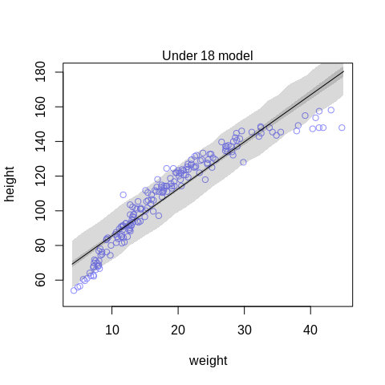

```r
weight.seq <- seq(from=4, to=45, length.out = 30)
post <- extract.samples(model18)

mu <- link( model18, data = list(weight = weight.seq))
mu.mean <- apply(mu, 2, mean)
mu.PI <- apply(mu, 2, PI, prob=0.89)

sim.height <- sim( model18, data = list(weight = weight.seq ))
height.PI <- apply(sim.height, 2, PI, prob=0.89)

# plot everything
plot(height ~ weight, data=d18, col=col.alpha(rangi2, 0.9), ylim=c(50, 180))   # the raw data
lines(weight.seq, mu.mean)                                      # the MAP regression line
shade( mu.PI, weight.seq)                                     # draw PI region around the regression line
shade( height.PI, weight.seq)                                 # draw PI region for the simulated heights
mtext("Under 18 model")
```

3. What aspects of the model fit concern you?

The linear model doesn’t seem to be a very good fit for the data. It performs very poorly for the lower and higher values of weight. One possibility to improve the model could be to use a polynomial model (e.g. of 2nd order) instead.

**4H3.** A colleague exclaims: “Only the *logarithm* of body weight scales with height!” Let’s try this out.

1. Use the entire `Howell1` data frame using the following model:
   $$\begin{align*}
   h_i &\sim \text{Normal}(\mu_i, \sigma) \\
   \mu_i &= \alpha + \beta (\log(w_i) - \bar{x}_l) \\
   \alpha &\sim \text{Normal}(178, 20) \\
   \beta &\sim \text{Log-Normal}(0, 1) \\
   \sigma &\sim \text{Uniform}(0, 50)
   \end{align*}$$
   The value $\bar{x}_l$ is the mean of the log-weights. Here the model description in R:

```r
d <- Howell1
xbarl <- mean( log( d$weight ) )

model.l <- quap(
  alist(
    height ~ dnorm( mu, sigma) ,
    mu <- a + b*( log( weight ) - xbarl ),
    a ~ dnorm( 178, 20) ,
    b ~ dlnorm( 0, 1) ,
    sigma ~ dunif(0, 50)
  ),
  data=d
)
precis(model.l)
```

```
        mean    sd   5.5%  94.5%
a     138.27 0.220 137.92 138.62
b      47.07 0.383  46.46  47.68
sigma   5.13 0.156   4.89   5.38
```

Interpreting these results is a bit more difficult since we transformed the weights using the logarithm. The intercept `a` corresponds to the average height of someone whose log-weight is equal to the mean of log-weights, i.e. whose weight is 31kg (this is equivalent to the geometric mean). How to interpret the `b` value? If we increase the weight by $p$ percent (ignoring the centralization term for now), we get the following expression for $\mu$:
$$\begin{align*}
\mu &= \alpha + \beta \log(\text{weight} \times (1 + p) )
\end{align*}$$
Using some rules for logarithms, we get:
$$\begin{align*}
\mu &= \alpha + \beta \log(\text{weight}) + \beta \log(1 + p)
\end{align*}$$
That is, an increase of $p$ percent in the weight variable is associated with an increase of $\mu$ of $\beta \log(1 + p)$. I personally find this not super intuitive, so let’s have a look at some plots as well. We compute again the mean $\mu$ and its compatibility interval as well as simulate predictions for the height.

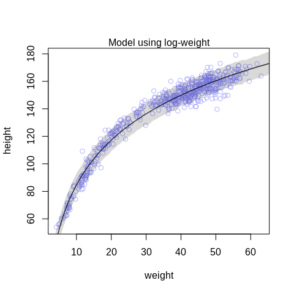

```r
weight.seq <- seq(from=2, to=70, length.out = 100)
post <- extract.samples(model.l)
# compute mu
mu <- link( model.l, data = list(weight = weight.seq))
mu.mean <- apply(mu, 2, mean)  # MAP line
mu.PI <- apply(mu, 2, PI, prob=0.89)

# compute predicted height
sim.height <- sim( model.l, data = list(weight = weight.seq))
height.PI <- apply(sim.height, 2, PI, prob=0.89)

# the plot
plot(height ~ weight, data=d, col=col.alpha(rangi2, 0.6))
lines(weight.seq, mu.mean)                                      # the MAP regression line
shade( mu.PI, weight.seq)                                     # draw PI region around the regression line
shade( height.PI, weight.seq)                                # draw PI region for the simulated heights
mtext("Model using log-weight")
```

Compared to the model above fit to only the children and also compared to the models earlier in the chapter using the full data set with polynomial regression, this model seems to perform quite well on the data.

We can also visualize the model on log scale:

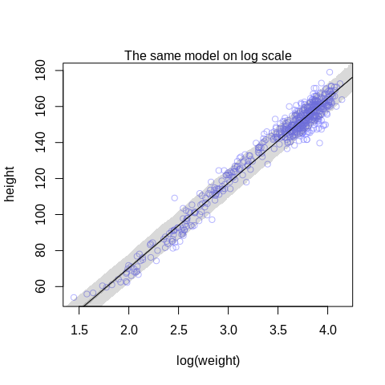

Given the last two plots, I’d say the colleague was right: The logarithm of body weight scales very well with height.

**4H4.** [WIP]

**4H5.**

**4H6.**

**4H7.**

[Full code.](https://github.com/corriebar/statrethinking_reading_group/blob/master/chapter_4/chapter4_ex.Rmd)